# Part 2 - Antarctic Penguin Data Processing and Exploration

2025-10-22

## Data Structure Diagnosis

**Reading data and importing libraries**

```r
library(tidyverse)
library(dplyr)
data<-read_csv("antarctic_penguins.csv")
```

**Variable Renaming**

```r
data <- data %>%
  rename(sample_number = `Sample Number`, date_egg = `Date Egg`)
```

**Date Conversion**

The Date Egg variable records the date when each penguin nest was first observed with one egg.Since penguin breeding typically occurs between September and November, the U.S. date format (MM/DD/YYYY) is the most suitable choice. Years incorrectly recorded as 0007, 0008, etc., are corrected to 2007, 2008, and so on.

```r
# Fix years like 0007 → 2007
data <- data %>%
  mutate(
    date_egg = as.Date(date_egg, format = "%m/%d/%Y"),
    date_egg = if_else(year(date_egg) < 2000,
                       date_egg + years(2000),
                       date_egg)
  )
```

**Simplifying Species Names**

The full species names include both the common and scientific names. Since the first two words uniquely identify each species, we retain only those for simplicity.

```r
data$Species <- sub(" \\(.*\\)", "", data$Species)
```

**Removing Unnecessary Columns**

Some columns contain only a single value across all records (e.g., `Region`, `Stage`) and thus do not contribute analytical value. These, along with the Individual ID, are dropped to simplify the dataset.

```r
print(unique(data$Region))
```

```
## [1] "Anvers"
```

```r
print(unique(data$Stage))
```

```
## [1] "Adult, 1 Egg Stage"
```

All samples are from the “Anvers” region and are at the “Adult, 1 Egg Stage”.

```r
data<-data %>%
  select(-Region, -Stage, -`Individual ID`)
```

It is observed that the year of each sample is tightly connected to the `studyName` variable.

```r
data <- data %>%
  mutate(year_egg = year(date_egg))

# Check  what are the different years for each Study Name
check_sample_years <- data %>%
  group_by(studyName) %>%
  summarise(year_range = paste(sort(unique(year_egg)), collapse = ", "),
            n_records = n()) %>%
  arrange(studyName)

print(check_sample_years)
```

```
## # A tibble: 3 × 3
##   studyName year_range n_records
##   <chr>     <chr>          <int>
## 1 PAL0708   2007             110
## 2 PAL0809   2008             114
## 3 PAL0910   2009             120
```

The first digits in each `studyName` correspond to the collection year. Since both `date_egg` and `year_egg` already capture this information, we drop `studyName` and the sequential sample_number.

```r
data<-data %>%
  select(-studyName, -sample_number)
```

**Removing Empty Records**

A few rows correspond to unsampled penguins with missing measurement data. These are excluded from the dataset.

```r
data<-data %>%
  filter(!if_all(`Culmen Length (mm)`:`Delta 15 N (o/oo)`, is.na))
```

**Fixing Sex Column Anomalies**

One sample contains a single dot “.” instead of a valid sex value. This is replaced with NA for consistency.

```r
data<-data %>%
  mutate(Sex = na_if(Sex, "."))
```

**Estimating Missing Sex Values**

In nature, males are typically larger than females. We use morphological features — culmen area, flipper length, and body mass — to estimate missing Sex values.

The following code:

1. Calculates culmen area (length × depth).
2. Computes mean measurements per species and sex.
3. Imputes missing sex values by comparing proximity to male and female averages.
4. Creates new imputed versions of Sex based on each predictor.

```r
data_imputed <- data %>%
  # --- Compute derived measures ---
  mutate(
    culmen_area = `Culmen Length (mm)` * `Culmen Depth (mm)`
  ) %>%

  # --- Calculate mean values for each predictor by Species and Sex ---
  group_by(Species, Sex) %>%
  mutate(
    mean_area_by_species_sex    = mean(culmen_area, na.rm = TRUE),
    mean_flipper_by_species_sex = mean(`Flipper Length (mm)`, na.rm = TRUE),
    mean_mass_by_species_sex    = mean(`Body Mass (g)`, na.rm = TRUE)
  ) %>%
  ungroup() %>%

  # Impute Sex based on difference between flipper length, culmen area, body mass
  group_by(Species) %>%
  mutate(
    imputed_sex_culmen = case_when(
      is.na(Sex) & abs(culmen_area - mean_area_by_species_sex[Sex == "MALE"][1]) <abs(culmen_area - mean_area_by_species_sex[Sex == "FEMALE"][1]) ~ "MALE",
      is.na(Sex) & abs(culmen_area - mean_area_by_species_sex[Sex == "FEMALE"][1]) <abs(culmen_area - mean_area_by_species_sex[Sex == "MALE"][1]) ~ "FEMALE",TRUE ~ Sex
    ),
    imputed_sex_flipper = case_when(
      is.na(Sex) & abs(`Flipper Length (mm)` - mean_flipper_by_species_sex[Sex == "MALE"][1]) <abs(`Flipper Length (mm)` - mean_flipper_by_species_sex[Sex == "FEMALE"][1]) ~ "MALE",
      is.na(Sex) & abs(`Flipper Length (mm)` - mean_flipper_by_species_sex[Sex == "FEMALE"][1]) <abs(`Flipper Length (mm)` - mean_flipper_by_species_sex[Sex == "MALE"][1]) ~"FEMALE",TRUE ~ Sex
    ),
    imputed_sex_mass = case_when(
      is.na(Sex) & abs(`Body Mass (g)` - mean_mass_by_species_sex[Sex == "MALE"][1]) <abs(`Body Mass (g)` - mean_mass_by_species_sex[Sex == "FEMALE"][1]) ~ "MALE",
      is.na(Sex) & abs(`Body Mass (g)` - mean_mass_by_species_sex[Sex == "FEMALE"][1]) <abs(`Body Mass (g)` - mean_mass_by_species_sex[Sex == "MALE"][1]) ~ "FEMALE",TRUE ~ Sex
    )
  )

data_imputed %>%
  filter(is.na(Sex))
```

```
## # A tibble: 9 × 20
## # Groups:   Species [2]
##   Species        Island    `Clutch Completion` date_egg   `Culmen Length (mm)`
##   <chr>          <chr>     <chr>               <date>                    <dbl>
## 1 Adelie Penguin Torgersen Yes                 2007-11-09                 34.1
## 2 Adelie Penguin Torgersen Yes                 2007-11-09                 42
## 3 Adelie Penguin Torgersen Yes                 2007-11-09                 37.8
## 4 Adelie Penguin Torgersen Yes                 2007-11-09                 37.8
## 5 Adelie Penguin Dream     Yes                 2007-11-13                 37.5
## 6 Gentoo penguin Biscoe    Yes                 2007-11-29                 44.5
## 7 Gentoo penguin Biscoe    Yes                 2008-11-09                 46.2
## 8 Gentoo penguin Biscoe    Yes                 2009-12-01                 47.3
## 9 Gentoo penguin Biscoe    Yes                 2009-12-01                 44.5
## # ℹ 15 more variables: `Culmen Depth (mm)` <dbl>, `Flipper Length (mm)` <dbl>,
## #   `Body Mass (g)` <dbl>, Sex <chr>, `Delta 15 N (o/oo)` <dbl>,
## #   `Delta 13 C (o/oo)` <dbl>, Comments <chr>, year_egg <dbl>,
## #   culmen_area <dbl>, mean_area_by_species_sex <dbl>,
## #   mean_flipper_by_species_sex <dbl>, mean_mass_by_species_sex <dbl>,
## #   imputed_sex_culmen <chr>, imputed_sex_flipper <chr>, imputed_sex_mass <chr>
```

The imputation based on body mass is chosen as the most consistent predictor. The following code replaces missing values in the Sex column accordingly.

```r
data_imputed <- data_imputed %>%
  mutate(
    Sex = case_when(
      is.na(Sex) ~ imputed_sex_mass,
      TRUE ~ Sex
    )
  )
data<- data_imputed %>%
  select(-c(mean_area_by_species_sex:imputed_sex_mass))
```

**Visual Validation**

The following box plots provide a visual check of the sex-based morphological differences.

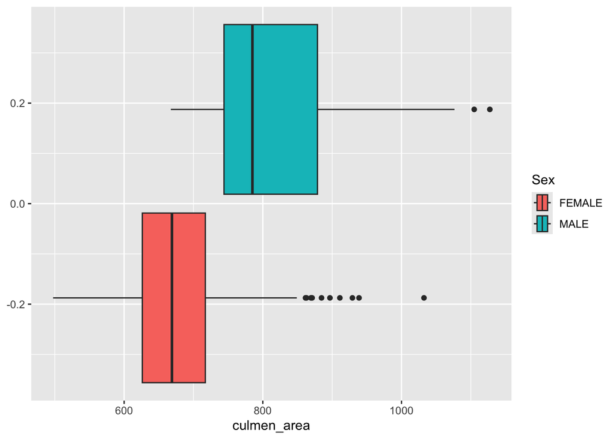

```r
ggplot(data_imputed, aes(x=culmen_area, fill = Sex)) +
    geom_boxplot()
```

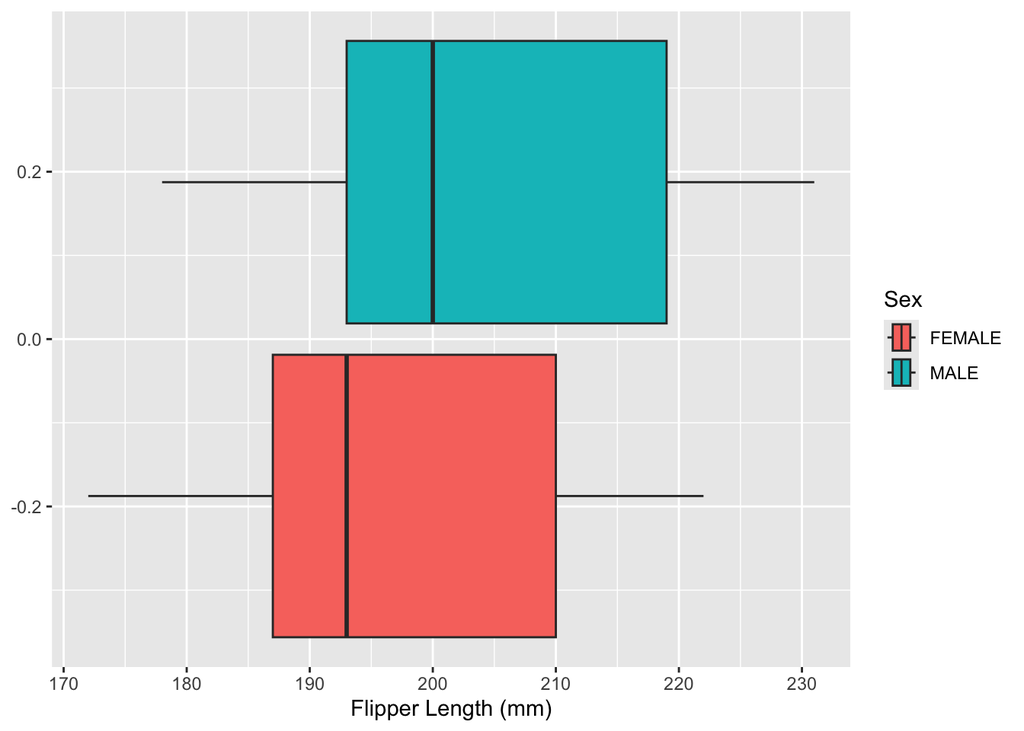

```r
ggplot(data_imputed, aes(x=`Flipper Length (mm)`, fill = Sex)) +
    geom_boxplot()
```

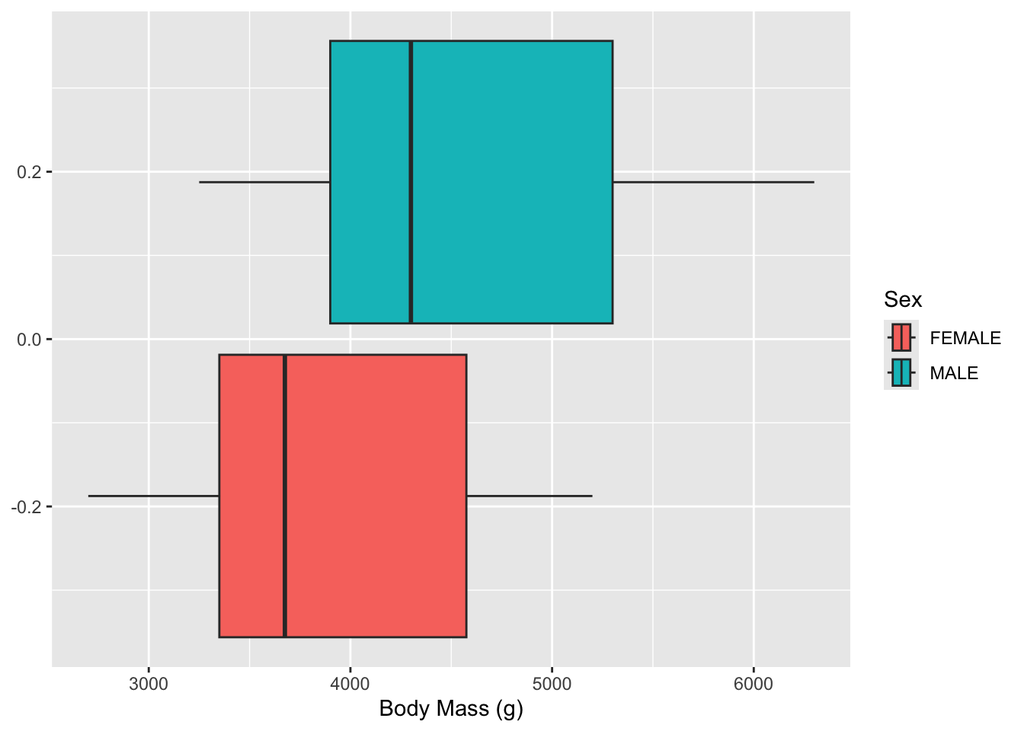

```r
ggplot(data_imputed, aes(x=`Body Mass (g)`, fill = Sex)) +
    geom_boxplot()
```

**Saving the Processed Dataset**

```r
write.csv(data, "peng_processed.csv", row.names = FALSE)
```